# Project 1: Wrangling, Exploration, Visualization

SDS322E

## Data Wrangling, Exploration, Visualization

### Seungho Lee; SL46699

#### Introduction

*I have decided to utilize the nbaplayers dataset and nbastats as my two datasets for my project. The nbaplayers dataset involves the players from the 2018-2019 season of the NBA and includes variables such as players’ first and last names, team names, team city abbreviations, positions of each player, jersey number of players, and the height of players listed in inches. I have also utilized the nbastats dataset which involves the stat record of all the NBA players from the 2018-2019 season and includes variables such as name, weight, age, salary, points, blocks, steals, assists, rebounds, free throw percentages, field goal percentages, and minutes played. Growing up, basketball has always been a huge part of life. I loved playing basketball as well as watching NBA basketball. Whether I am on the court myself playing or watching my favorite player playing on TV, I was always engaged and interested in keeping up with the different statistics involved in the game of basketball.*

```r
# read your datasets in here, e.g., with read_csv()
library(tidyverse)
nbastats2018_2019_2 <- read_csv("nbastats2018-2019 2.csv", col_types = cols(Height = col_skip(),
    Weight = col_number(), Team = col_skip(), Age = col_number(),
    Salary = col_number(), Points = col_number(), Blocks = col_number(),
    Steals = col_number(), Assists = col_number(), Rebounds = col_number(),
    `FT%` = col_number(), FTA = col_skip(), `FG3%` = col_skip(),
    FG3A = col_skip(), `FG%` = col_number(), FGA = col_skip(),
    MP = col_number(), G = col_skip(), PER = col_skip(), OWS = col_skip(),
    DWS = col_skip(), WS = col_skip(), WS48 = col_skip(), USG = col_skip(),
    BPM = col_skip(), VORP = col_skip()))
nbastats <- nbastats2018_2019_2
nba_players_19 <- read_csv("nba_players_19.csv", col_types = cols(X1 = col_skip(),
    number = col_number(), height = col_number()))
nbaplayers <- nba_players_19
```

#### Tidying: Reshaping

*Both of my datasets were both very tidy. I have still provided below the utilization of pivot_wider and pivot_longer below. For the nbaplayers dataset, I have utilized the pivot_wider function in order to make the data go from 494 observations and 7 variables to 494 observations and 35 variables making the data overall “wider”. All the NBA team names were put into separate columns and for each player, the team city abbreviations were utilized as the values that were displayed under the matching respective teams (e.g. for player Bam Adebayo, a player for the Miami Heat, has the value “MIA” which is the city abbreviation for Miami under the Heat column). Additionally, for the nbastats dataset, I have utilized the pivot_longer function in order to make the data go from 521 observations and 12 variables to 1042 observations and 12 variables making the data overall “longer”. The values from the the second column “weight” and third column “age” were put under one column named “Weight/Age” and their respective values were displayed on the adjacent column.*

```r
# your tidying code (if applicable; can also wait until
# wrangling section)
nbaplayers %>% pivot_wider(names_from = "team", values_from = "team_abbr")
```

```
## # A tibble: 494 x 35
##    first_name last_name position number height Thunder Hawks Heat  Nuggets Spurs
##    <chr>      <chr>     <chr>     <dbl>  <dbl> <chr>   <chr> <chr> <chr>   <chr>
##  1 Alex       Abrines   Guard         8     78 OKC     <NA>  <NA>  <NA>    <NA>
##  2 Jaylen     Adams     Guard        10     74 <NA>    ATL   <NA>  <NA>    <NA>
##  3 Steven     Adams     Center       12     84 OKC     <NA>  <NA>  <NA>    <NA>
##  4 Bam        Adebayo   Center-…     13     82 <NA>    <NA>  MIA   <NA>    <NA>
##  5 DeVaughn   Akoon-Pu… Guard-F…     23     78 <NA>    <NA>  <NA>  DEN     <NA>
##  6 LaMarcus   Aldridge  Forward      12     83 <NA>    <NA>  <NA>  <NA>    SAS
##  7 Rawle      Alkins    Guard        20     77 <NA>    <NA>  <NA>  <NA>    <NA>
##  8 Grayson    Allen     Guard        24     77 <NA>    <NA>  <NA>  <NA>    <NA>
##  9 Jarrett    Allen     Center       31     83 <NA>    <NA>  <NA>  <NA>    <NA>
## 10 Al-Farouq  Aminu     Forward       8     81 <NA>    <NA>  <NA>  <NA>    <NA>
## # … with 484 more rows, and 25 more variables: Bulls <chr>, Jazz <chr>,
## #   Nets <chr>, Blazers <chr>, Grizzlies <chr>, Suns <chr>, Pacers <chr>,
## #   Bucks <chr>, Mavericks <chr>, Rockets <chr>, Raptors <chr>, Magic <chr>,
## #   Hornets <chr>, Kings <chr>, Knicks <chr>, Lakers <chr>, Timberwolves <chr>,
## #   Celtics <chr>, Wizards <chr>, Warriors <chr>, Clippers <chr>,
## #   Pelicans <chr>, Sixers <chr>, Pistons <chr>, Cavaliers <chr>
```

```r
nbastats %>% pivot_longer(2:3, names_to = "Weight/Age", values_to = "Value")
```

```
## # A tibble: 1,042 x 12
##    Name  Salary Points Blocks Steals Assists Rebounds `FT%` `FG%`    MP
##    <chr>  <dbl>  <dbl>  <dbl>  <dbl>   <dbl>    <dbl> <dbl> <dbl> <dbl>
##  1 Alex… 5.46e6    5.3    0.2    0.5     0.6      1.5 0.923 0.357  19
##  2 Alex… 5.46e6    5.3    0.2    0.5     0.6      1.5 0.923 0.357  19
##  3 Quin… 2.14e5    1.7    0.4    0.1     0.8      2.5 0.7   0.222  12.3
##  4 Quin… 2.14e5    1.7    0.4    0.1     0.8      2.5 0.7   0.222  12.3
##  5 Jayl… 2.37e5    3.2    0.1    0.4     1.9      1.8 0.778 0.345  12.6
##  6 Jayl… 2.37e5    3.2    0.1    0.4     1.9      1.8 0.778 0.345  12.6
##  7 Stev… 2.42e7   13.9    1      1.5     1.6      9.5 0.5   0.595  33.4
##  8 Stev… 2.42e7   13.9    1      1.5     1.6      9.5 0.5   0.595  33.4
##  9 Bam … 2.96e6    8.9    0.8    0.9     2.2      7.3 0.735 0.576  23.3
## 10 Bam … 2.96e6    8.9    0.8    0.9     2.2      7.3 0.735 0.576  23.3
## # … with 1,032 more rows, and 2 more variables: `Weight/Age` <chr>, Value <dbl>
```

#### Joining/Merging

```r
# your joining code
nbaplayers$name <- paste(nbaplayers$first_name, nbaplayers$last_name,
    sep = " ")
glimpse(nbastats)
```

```
## Rows: 521
## Columns: 12
## $ Name     <chr> "Alex Abrines", "Quincy Acy", "Jaylen Adams", "Steven Adams"…
## $ Weight   <dbl> 200, 240, 190, 265, 255, 200, 260, 225, 198, 237, 192, 220, …
## $ Age      <dbl> 25, 28, 22, 25, 21, 21, 33, 21, 23, 20, 26, 28, 25, 25, 20, …
## $ Salary   <dbl> 5455236, 213949, 236854, 24157304, 2955840, NA, 22347015, NA…
## $ Points   <dbl> 5.3, 1.7, 3.2, 13.9, 8.9, 1.7, 21.3, 3.7, 5.6, 10.9, 9.9, 9.…
## $ Blocks   <dbl> 0.2, 0.4, 0.1, 1.0, 0.8, 0.2, 1.3, 0.0, 0.2, 1.5, 0.2, 0.4, …
## $ Steals   <dbl> 0.5, 0.1, 0.4, 1.5, 0.9, 0.1, 0.5, 0.1, 0.2, 0.5, 0.8, 0.8, …
## $ Assists  <dbl> 0.6, 0.8, 1.9, 1.6, 2.2, 0.3, 2.4, 1.3, 0.7, 1.4, 4.0, 1.3, …
## $ Rebounds <dbl> 1.5, 2.5, 1.8, 9.5, 7.3, 1.0, 9.2, 2.6, 0.6, 8.4, 2.7, 7.5, …
## $ `FT%`    <dbl> 0.923, 0.700, 0.778, 0.500, 0.735, 1.000, 0.847, 0.667, 0.75…
## $ `FG%`    <dbl> 0.357, 0.222, 0.345, 0.595, 0.576, 0.306, 0.519, 0.333, 0.37…
## $ MP       <dbl> 19.0, 12.3, 12.6, 33.4, 23.3, 10.2, 33.2, 12.0, 10.9, 26.2, …
```

```r
glimpse(nbaplayers)
```

```
## Rows: 494
## Columns: 8
## $ first_name <chr> "Alex", "Jaylen", "Steven", "Bam", "DeVaughn", "LaMarcus",…
## $ last_name  <chr> "Abrines", "Adams", "Adams", "Adebayo", "Akoon-Purcell", "…
## $ team       <chr> "Thunder", "Hawks", "Thunder", "Heat", "Nuggets", "Spurs",…
## $ team_abbr  <chr> "OKC", "ATL", "OKC", "MIA", "DEN", "SAS", "CHI", "UTA", "B…
## $ position   <chr> "Guard", "Guard", "Center", "Center-Forward", "Guard-Forwa…
## $ number     <dbl> 8, 10, 12, 13, 23, 12, 20, 24, 31, 8, 1, 1, 15, 13, 34, 37…
## $ height     <dbl> 78, 74, 84, 82, 78, 83, 77, 77, 83, 81, 78, 81, 82, 82, 83…
## $ name       <chr> "Alex Abrines", "Jaylen Adams", "Steven Adams", "Bam Adeba…
```

```r
nbastats %>% distinct()
```

```
## # A tibble: 521 x 12
##    Name  Weight   Age  Salary Points Blocks Steals Assists Rebounds `FT%` `FG%`
##    <chr>  <dbl> <dbl>   <dbl>  <dbl>  <dbl>  <dbl>   <dbl>    <dbl> <dbl> <dbl>
##  1 Alex…    200    25  5.46e6    5.3    0.2    0.5     0.6      1.5 0.923 0.357
##  2 Quin…    240    28  2.14e5    1.7    0.4    0.1     0.8      2.5 0.7   0.222
##  3 Jayl…    190    22  2.37e5    3.2    0.1    0.4     1.9      1.8 0.778 0.345
##  4 Stev…    265    25  2.42e7   13.9    1      1.5     1.6      9.5 0.5   0.595
##  5 Bam …    255    21  2.96e6    8.9    0.8    0.9     2.2      7.3 0.735 0.576
##  6 Deng…    200    21 NA         1.7    0.2    0.1     0.3      1   1     0.306
##  7 LaMa…    260    33  2.23e7   21.3    1.3    0.5     2.4      9.2 0.847 0.519
##  8 Rawl…    225    21 NA         3.7    0      0.1     1.3      2.6 0.667 0.333
##  9 Gray…    198    23  2.07e6    5.6    0.2    0.2     0.7      0.6 0.75  0.376
## 10 Jarr…    237    20  2.03e6   10.9    1.5    0.5     1.4      8.4 0.709 0.59
## # … with 511 more rows, and 1 more variable: MP <dbl>
```

```r
nbaplayers %>% distinct()
```

```
## # A tibble: 494 x 8
##    first_name last_name   team   team_abbr position   number height name
##    <chr>      <chr>       <chr>  <chr>     <chr>       <dbl>  <dbl> <chr>
##  1 Alex       Abrines     Thund… OKC       Guard           8     78 Alex Abrines
##  2 Jaylen     Adams       Hawks  ATL       Guard          10     74 Jaylen Adams
##  3 Steven     Adams       Thund… OKC       Center         12     84 Steven Adams
##  4 Bam        Adebayo     Heat   MIA       Center-Fo…     13     82 Bam Adebayo
##  5 DeVaughn   Akoon-Purc… Nugge… DEN       Guard-For…     23     78 DeVaughn Ak…
##  6 LaMarcus   Aldridge    Spurs  SAS       Forward        12     83 LaMarcus Al…
##  7 Rawle      Alkins      Bulls  CHI       Guard          20     77 Rawle Alkins
##  8 Grayson    Allen       Jazz   UTA       Guard          24     77 Grayson All…
##  9 Jarrett    Allen       Nets   BKN       Center         31     83 Jarrett All…
## 10 Al-Farouq  Aminu       Blaze… POR       Forward         8     81 Al-Farouq A…
## # … with 484 more rows
```

```r
anti_join(nbastats, nbaplayers, by = c(Name = "name"))
```

```
## # A tibble: 65 x 12
##    Name  Weight   Age  Salary Points Blocks Steals Assists Rebounds  `FT%` `FG%`
##    <chr>  <dbl> <dbl>   <dbl>  <dbl>  <dbl>  <dbl>   <dbl>    <dbl>  <dbl> <dbl>
##  1 Quin…    240    28  213949    1.7    0.4    0.1     0.8      2.5  0.7   0.222
##  2 Deng…    200    21      NA    1.7    0.2    0.1     0.3      1    1     0.306
##  3 Kade…    192    26      NA    9.9    0.2    0.8     4        2.7  0.778 0.461
##  4 Wade…    200    22 1544951    1.9    0.1    0.1     0.8      0.9  0.727 0.303
##  5 Moha…    221    20 4865040    6.2    1.4    0.3     0.8      5    0.587 0.481
##  6 Dair…    200    29  194220    2.8    0      0.1     0.8      0.8 NA     0.255
##  7 Jaro…    220    25      NA    4.2    0.3    0.3     0.5      3.6  0.769 0.443
##  8 Andr…    260    34 2393887    3.5    0.7    0.3     1        5    1     0.5
##  9 Core…    186    32  270496    4.9    0.2    1       1.3      2.5  0.721 0.431
## 10 Brun…    218    23  487000    8.3    1      0.4     1.5      4.6  0.84  0.427
## # … with 55 more rows, and 1 more variable: MP <dbl>
```

```r
nomatch <- anti_join(nbastats, nbaplayers, by = c(Name = "name"))
anti_join(nbaplayers, nbastats, by = c(name = "Name"))
```

```
## # A tibble: 38 x 8
##    first_name last_name   team   team_abbr position   number height name
##    <chr>      <chr>       <chr>  <chr>     <chr>       <dbl>  <dbl> <chr>
##  1 DeVaughn   Akoon-Purc… Nugge… DEN       Guard-For…     23     78 DeVaughn Ak…
##  2 Ryan       Anderson    Suns   PHX       Forward        15     82 Ryan Anders…
##  3 Wade       Baldwin IV  Blaze… POR       Guard           2     76 Wade Baldwi…
##  4 Mo         Bamba       Magic  ORL       Center          5     84 Mo Bamba
##  5 Jabari     Bird        Celti… BOS       Guard          NA     78 Jabari Bird
##  6 Trevon     Bluiett     Pelic… NOP       Guard-For…      5     78 Trevon Blui…
##  7 Tyler      Davis       Thund… OKC       Center         34     82 Tyler Davis
##  8 Vincent    Edwards     Rocke… HOU       Forward        12     80 Vincent Edw…
##  9 James      Ennis III   Rocke… HOU       Forward         8     79 James Ennis…
## 10 Keenan     Evans       Pisto… DET       Guard          12     75 Keenan Evans
## # … with 28 more rows
```

```r
nomatch2 <- anti_join(nbaplayers, nbastats, by = c(name = "Name"))

# your joining code
inner_join(nbastats, nbaplayers, by = c(Name = "name"))
```

```
## # A tibble: 456 x 19
##    Name  Weight   Age  Salary Points Blocks Steals Assists Rebounds `FT%` `FG%`
##    <chr>  <dbl> <dbl>   <dbl>  <dbl>  <dbl>  <dbl>   <dbl>    <dbl> <dbl> <dbl>
##  1 Alex…    200    25  5.46e6    5.3    0.2    0.5     0.6      1.5 0.923 0.357
##  2 Jayl…    190    22  2.37e5    3.2    0.1    0.4     1.9      1.8 0.778 0.345
##  3 Stev…    265    25  2.42e7   13.9    1      1.5     1.6      9.5 0.5   0.595
##  4 Bam …    255    21  2.96e6    8.9    0.8    0.9     2.2      7.3 0.735 0.576
##  5 LaMa…    260    33  2.23e7   21.3    1.3    0.5     2.4      9.2 0.847 0.519
##  6 Rawl…    225    21 NA         3.7    0      0.1     1.3      2.6 0.667 0.333
##  7 Gray…    198    23  2.07e6    5.6    0.2    0.2     0.7      0.6 0.75  0.376
##  8 Jarr…    237    20  2.03e6   10.9    1.5    0.5     1.4      8.4 0.709 0.59
##  9 Al-F…    220    28  6.96e6    9.4    0.4    0.8     1.3      7.5 0.867 0.433
## 10 Just…    230    25  2.52e6    3.7    0.3    0.5     0.5      1.8 0.743 0.408
## # … with 446 more rows, and 8 more variables: MP <dbl>, first_name <chr>,
## #   last_name <chr>, team <chr>, team_abbr <chr>, position <chr>, number <dbl>,
## #   height <dbl>
```

```r
joinedNBAdata <- inner_join(nbastats, nbaplayers, by = c(Name = "name")) %>%
    select(-first_name, -last_name)
joinedNBAdata
```

```
## # A tibble: 456 x 17
##    Name  Weight   Age  Salary Points Blocks Steals Assists Rebounds `FT%` `FG%`
##    <chr>  <dbl> <dbl>   <dbl>  <dbl>  <dbl>  <dbl>   <dbl>    <dbl> <dbl> <dbl>
##  1 Alex…    200    25  5.46e6    5.3    0.2    0.5     0.6      1.5 0.923 0.357
##  2 Jayl…    190    22  2.37e5    3.2    0.1    0.4     1.9      1.8 0.778 0.345
##  3 Stev…    265    25  2.42e7   13.9    1      1.5     1.6      9.5 0.5   0.595
##  4 Bam …    255    21  2.96e6    8.9    0.8    0.9     2.2      7.3 0.735 0.576
##  5 LaMa…    260    33  2.23e7   21.3    1.3    0.5     2.4      9.2 0.847 0.519
##  6 Rawl…    225    21 NA         3.7    0      0.1     1.3      2.6 0.667 0.333
##  7 Gray…    198    23  2.07e6    5.6    0.2    0.2     0.7      0.6 0.75  0.376
##  8 Jarr…    237    20  2.03e6   10.9    1.5    0.5     1.4      8.4 0.709 0.59
##  9 Al-F…    220    28  6.96e6    9.4    0.4    0.8     1.3      7.5 0.867 0.433
## 10 Just…    230    25  2.52e6    3.7    0.3    0.5     0.5      1.8 0.743 0.408
## # … with 446 more rows, and 6 more variables: MP <dbl>, team <chr>,
## #   team_abbr <chr>, position <chr>, number <dbl>, height <dbl>
```

```r
joinedNBAdata <- joinedNBAdata %>% na.omit()
joinedNBAdata
```

```
## # A tibble: 417 x 17
##    Name  Weight   Age Salary Points Blocks Steals Assists Rebounds `FT%` `FG%`
##    <chr>  <dbl> <dbl>  <dbl>  <dbl>  <dbl>  <dbl>   <dbl>    <dbl> <dbl> <dbl>
##  1 Alex…    200    25 5.46e6    5.3    0.2    0.5     0.6      1.5 0.923 0.357
##  2 Jayl…    190    22 2.37e5    3.2    0.1    0.4     1.9      1.8 0.778 0.345
##  3 Stev…    265    25 2.42e7   13.9    1      1.5     1.6      9.5 0.5   0.595
##  4 Bam …    255    21 2.96e6    8.9    0.8    0.9     2.2      7.3 0.735 0.576
##  5 LaMa…    260    33 2.23e7   21.3    1.3    0.5     2.4      9.2 0.847 0.519
##  6 Gray…    198    23 2.07e6    5.6    0.2    0.2     0.7      0.6 0.75  0.376
##  7 Jarr…    237    20 2.03e6   10.9    1.5    0.5     1.4      8.4 0.709 0.59
##  8 Al-F…    220    28 6.96e6    9.4    0.4    0.8     1.3      7.5 0.867 0.433
##  9 Just…    230    25 2.52e6    3.7    0.3    0.5     0.5      1.8 0.743 0.408
## 10 Kyle…    230    25 8.64e6    8      0.9    1.3     3        5.8 0.578 0.543
## # … with 407 more rows, and 6 more variables: MP <dbl>, team <chr>,
## #   team_abbr <chr>, position <chr>, number <dbl>, height <dbl>
```

*Prior to joining the two datasets together, a separate column had to be made for nbaplayers called “name” because the first and last names were split in this dataset for every NBA athlete. In the nbastats datasets there are 521 observations while the nbaplyers dataset has 494 observations. Since there is no duplicate NBA players in each dataset, the unique IDs are equivalent to the obserations/rows for each dataset. There are 65 players listed in nbastats but not listed in nbaplayers. There are 38 players listed in nbaplayers, but not listed in nbastats. After joining the two datasets utilizing inner_join, it showed that the two datasets have 456 names in common (456 observations and 19 variables). This made sense that the common names between the two datasets were 456. From the previous code involving “nomatch”, it shows how there are 65 player names exclusive to nbastats, so 65 names were dropped from the nbastats datasets (521 minus 65 = 456). Similary, from “nomatch2”, it shows how there are 38 player names that are exclusive to nbaplayers, so 38 names were dropped from the nbaplayers datasets (494 minus 38 = 456). I have decided to utilize the inner_join code instead of other joining codes such as semi_join because I wanted to work with all the stats of the players and the character variables such as the players’ team names and players’ positions. I have also went ahead and dropped the first_name and last_name columns that came from the nbaplayers dataset because those columns were not needed anymore (456 observations and 17 variables now). With the joined data, I also went ahead and deleted all the rows that had NAs (417 observations and and 17 variables now).*

#### Wrangling

```r
# your wrangling code
joinedNBAdata %>% mutate(pointspermin = Points/MP)
```

```
## # A tibble: 417 x 18
##    Name  Weight   Age Salary Points Blocks Steals Assists Rebounds `FT%` `FG%`
##    <chr>  <dbl> <dbl>  <dbl>  <dbl>  <dbl>  <dbl>   <dbl>    <dbl> <dbl> <dbl>
##  1 Alex…    200    25 5.46e6    5.3    0.2    0.5     0.6      1.5 0.923 0.357
##  2 Jayl…    190    22 2.37e5    3.2    0.1    0.4     1.9      1.8 0.778 0.345
##  3 Stev…    265    25 2.42e7   13.9    1      1.5     1.6      9.5 0.5   0.595
##  4 Bam …    255    21 2.96e6    8.9    0.8    0.9     2.2      7.3 0.735 0.576
##  5 LaMa…    260    33 2.23e7   21.3    1.3    0.5     2.4      9.2 0.847 0.519
##  6 Gray…    198    23 2.07e6    5.6    0.2    0.2     0.7      0.6 0.75  0.376
##  7 Jarr…    237    20 2.03e6   10.9    1.5    0.5     1.4      8.4 0.709 0.59
##  8 Al-F…    220    28 6.96e6    9.4    0.4    0.8     1.3      7.5 0.867 0.433
##  9 Just…    230    25 2.52e6    3.7    0.3    0.5     0.5      1.8 0.743 0.408
## 10 Kyle…    230    25 8.64e6    8      0.9    1.3     3        5.8 0.578 0.543
## # … with 407 more rows, and 7 more variables: MP <dbl>, team <chr>,
## #   team_abbr <chr>, position <chr>, number <dbl>, height <dbl>,
## #   pointspermin <dbl>
```

```r
LakersRoster <- joinedNBAdata %>% filter(team == "Lakers") %>%
    select(Name, Age) %>% arrange(desc(Age))
LakersRoster
```

```
## # A tibble: 14 x 2
##    Name                       Age
##    <chr>                    <dbl>
##  1 Tyson Chandler              36
##  2 LeBron James                34
##  3 Rajon Rondo                 32
##  4 JaVale McGee                31
##  5 Michael Beasley             30
##  6 Lance Stephenson            28
##  7 Kentavious Caldwell-Pope    25
##  8 Josh Hart                   23
##  9 Kyle Kuzma                  23
## 10 Lonzo Ball                  21
## 11 Brandon Ingram              21
## 12 Moritz Wagner               21
## 13 Ivica Zubac                 21
## 14 Isaac Bonga                 19
```

```r
joinedNBAdata %>% group_by(position) %>% summarize(n())
```

```
## # A tibble: 7 x 2
##   position       `n()`
##   <chr>          <int>
## 1 Center            49
## 2 Center-Forward     8
## 3 Forward          135
## 4 Forward-Center    22
## 5 Forward-Guard     10
## 6 Guard            166
## 7 Guard-Forward     27
```

```r
# your wrangling code
stringnba <- "LeBron James is the best player in the NBA today"
str_view_all(stringnba, "[aeiouAEIOU]")
```

[interactive chart not shown]

```r
# your wrangling code
joinedNBAdata %>% group_by(team) %>% summarize(mean_height = mean(height))
```

```
## # A tibble: 30 x 2
##    team      mean_height
##    <chr>           <dbl>
##  1 Blazers          79.4
##  2 Bucks            79.5
##  3 Bulls            79.1
##  4 Cavaliers        79.4
##  5 Celtics          78.7
##  6 Clippers         78.6
##  7 Grizzlies        79.1
##  8 Hawks            79
##  9 Heat             78.7
## 10 Hornets          78.8
## # … with 20 more rows
```

```r
joinedNBAdata %>% group_by(team_abbr) %>% summarize(n_distinct(position))
```

```
## # A tibble: 30 x 2
##    team_abbr `n_distinct(position)`
##    <chr>                      <int>
##  1 ATL                            6
##  2 BKN                            6
##  3 BOS                            3
##  4 CHA                            6
##  5 CHI                            5
##  6 CLE                            6
##  7 DAL                            6
##  8 DEN                            4
##  9 DET                            4
## 10 GSW                            4
## # … with 20 more rows
```

```r
joinedNBAdata %>% mutate(assist_ratiopermin = Assists/MP) %>%
    summarize(max(assist_ratiopermin))
```

```
## # A tibble: 1 x 1
##   `max(assist_ratiopermin)`
##                       <dbl>
## 1                     0.297
```

```r
joinedNBAdata %>% group_by(team) %>% summarize(sd(Salary))
```

```
## # A tibble: 30 x 2
##    team      `sd(Salary)`
##    <chr>            <dbl>
##  1 Blazers       9123988.
##  2 Bucks         6515362.
##  3 Bulls         6657133.
##  4 Cavaliers     7737594.
##  5 Celtics      10501459.
##  6 Clippers      5678616.
##  7 Grizzlies    10120091.
##  8 Hawks         5264102.
##  9 Heat          7737897.
## 10 Hornets       7057216.
## # … with 20 more rows
```

```r
joinedNBAdata %>% summarize(min(height))
```

```
## # A tibble: 1 x 1
##   `min(height)`
##           <dbl>
## 1            69
```

```r
joinedNBAdata %>% group_by(team) %>% summarize(max(Weight), max(Age),
    max(Points), max(Blocks), max(Steals), max(Assists), max(Rebounds),
    max(MP), max(height), max(Weight))
```

```
## # A tibble: 30 x 10
##    team  `max(Weight)` `max(Age)` `max(Points)` `max(Blocks)` `max(Steals)`
##    <chr>         <dbl>      <dbl>         <dbl>         <dbl>         <dbl>
##  1 Blaz…           275         30          25.8           1.4           1.1
##  2 Bucks           270         31          27.7           2.2           1.5
##  3 Bulls           275         30          23.7           1.3           1.5
##  4 Cava…           255         37          17             0.6           1.5
##  5 Celt…           260         32          23.8           1.3           1.8
##  6 Clip…           290         34          20             1.3           1.2
##  7 Griz…           255         34          21.1           1.4           1.3
##  8 Hawks           250         42          19.5           1.1           1.3
##  9 Heat            265         38          16.6           1.9           1.1
## 10 Horn…           255         36          25.6           0.8           1.2
## # … with 20 more rows, and 4 more variables: `max(Assists)` <dbl>,
## #   `max(Rebounds)` <dbl>, `max(MP)` <dbl>, `max(height)` <dbl>
```

```r
joinedNBAdata %>% group_by(team) %>% summarize(n())
```

```
## # A tibble: 30 x 2
##    team      `n()`
##    <chr>     <int>
##  1 Blazers      14
##  2 Bucks        16
##  3 Bulls        14
##  4 Cavaliers    14
##  5 Celtics      13
##  6 Clippers     15
##  7 Grizzlies    14
##  8 Hawks        16
##  9 Heat         14
## 10 Hornets      14
## # … with 20 more rows
```

```r
joinedNBAdata %>% group_by(team_abbr) %>% summarize(n())
```

```
## # A tibble: 30 x 2
##    team_abbr `n()`
##    <chr>     <int>
##  1 ATL          16
##  2 BKN          15
##  3 BOS          13
##  4 CHA          14
##  5 CHI          14
##  6 CLE          14
##  7 DAL          15
##  8 DEN          13
##  9 DET          15
## 10 GSW          14
## # … with 20 more rows
```

```r
joinedNBAdata %>% group_by(position) %>% summarize(n())
```

```
## # A tibble: 7 x 2
##   position       `n()`
##   <chr>          <int>
## 1 Center            49
## 2 Center-Forward     8
## 3 Forward          135
## 4 Forward-Center    22
## 5 Forward-Guard     10
## 6 Guard            166
## 7 Guard-Forward     27
```

```r
library(knitr)
joinedNBAdata %>% filter(team == "Mavericks") %>% kable(digits = 3,
    align = "c", col.names = str_to_title(names(.)))
```

| Name | Weight | Age | Salary | Points | Blocks | Steals | Assists | Rebounds | Ft% | Fg% | Mp | Team | Team_abbr | Position | Number | Height |
| --- | --- | --- | --- | --- | --- | --- | --- | --- | --- | --- | --- | --- | --- | --- | --- | --- |
| J.J. Barea | 185 | 34 | 3710850 | 10.9 | 0.0 | 0.6 | 5.6 | 2.5 | 0.705 | 0.418 | 19.8 | Mavericks | DAL | Guard | 5 | 72 |
| Harrison Barnes | 225 | 26 | 24107258 | 16.4 | 0.2 | 0.6 | 1.5 | 4.7 | 0.824 | 0.420 | 32.9 | Mavericks | DAL | Forward | 40 | 80 |
| Ryan Broekhoff | 215 | 28 | 838464 | 4.0 | 0.1 | 0.1 | 0.5 | 1.5 | 0.789 | 0.452 | 10.8 | Mavericks | DAL | Guard-Forward | 45 | 79 |
| Jalen Brunson | 190 | 22 | 1230000 | 9.3 | 0.1 | 0.5 | 3.2 | 2.3 | 0.725 | 0.467 | 21.8 | Mavericks | DAL | Guard | 13 | 75 |
| Luka Doncic | 218 | 19 | 6560640 | 21.2 | 0.3 | 1.1 | 6.0 | 7.8 | 0.713 | 0.427 | 32.2 | Mavericks | DAL | Forward-Guard | 77 | 79 |
| Dorian Finney-Smith | 220 | 25 | 1544951 | 7.5 | 0.4 | 0.9 | 1.2 | 4.8 | 0.709 | 0.432 | 24.5 | Mavericks | DAL | Forward | 10 | 80 |
| Devin Harris | 185 | 35 | 2393887 | 6.3 | 0.2 | 0.5 | 1.8 | 1.6 | 0.761 | 0.380 | 15.8 | Mavericks | DAL | Guard | 34 | 75 |
| DeAndre Jordan | 265 | 30 | 22900000 | 11.0 | 1.1 | 0.6 | 2.3 | 13.1 | 0.705 | 0.641 | 29.7 | Mavericks | DAL | Center | 6 | 83 |
| Maxi Kleber | 240 | 27 | 1378242 | 6.8 | 1.1 | 0.5 | 1.0 | 4.6 | 0.784 | 0.453 | 21.2 | Mavericks | DAL | Forward | 42 | 83 |
| Wesley Matthews | 220 | 32 | 18622514 | 12.2 | 0.2 | 0.8 | 2.3 | 2.5 | 0.810 | 0.400 | 30.3 | Mavericks | DAL | Guard-Forward | 23 | 77 |
| Salah Mejri | 235 | 32 | 1567007 | 3.9 | 0.7 | 0.3 | 1.0 | 3.6 | 0.625 | 0.491 | 11.1 | Mavericks | DAL | Center | 50 | 86 |
| Dirk Nowitzki | 245 | 40 | 5000000 | 7.3 | 0.4 | 0.2 | 0.7 | 3.1 | 0.780 | 0.359 | 15.6 | Mavericks | DAL | Forward | 41 | 84 |
| Dwight Powell | 240 | 27 | 9631250 | 10.6 | 0.6 | 0.6 | 1.5 | 5.3 | 0.772 | 0.597 | 21.6 | Mavericks | DAL | Forward-Center | 7 | 83 |
| Dennis Smith Jr. | 195 | 21 | 3819960 | 13.6 | 0.4 | 1.3 | 4.8 | 2.9 | 0.635 | 0.428 | 28.5 | Mavericks | DAL | Guard | 1 | 75 |
| Ray Spalding | 215 | 21 | 838464 | 3.9 | 0.6 | 0.6 | 0.4 | 3.4 | 0.333 | 0.532 | 10.6 | Mavericks | DAL | Forward | 26 | 82 |

#### Visualizing

```r
# your plot 1
library(ggplot2)
joinedNBAdata %>% filter(Age > 30)
```

```
## # A tibble: 68 x 17
##    Name  Weight   Age Salary Points Blocks Steals Assists Rebounds `FT%` `FG%`
##    <chr>  <dbl> <dbl>  <dbl>  <dbl>  <dbl>  <dbl>   <dbl>    <dbl> <dbl> <dbl>
##  1 LaMa…    260    33 2.23e7   21.3    1.3    0.5     2.4      9.2 0.847 0.519
##  2 Carm…    240    34 2.55e7   13.4    0.7    0.4     0.5      5.4 0.682 0.405
##  3 Trev…    215    33 1.50e7   12.5    0.3    1.3     3.7      5.4 0.793 0.399
##  4 D.J.…    183    31 7.25e6   11.7    0      0.6     5.3      2.5 0.866 0.47
##  5 J.J.…    185    34 3.71e6   10.9    0      0.6     5.6      2.5 0.705 0.418
##  6 Aron…    260    32 5.19e6    5.6    0.7    0.2     1.1      4.7 0.855 0.471
##  7 Marc…    210    32 6.15e6   10.5    0.1    0.4     1.7      2.5 0.903 0.413
##  8 Jose…    200    37 2.39e6    2.3    0.1    0.3     2.3      1.2 0.818 0.375
##  9 DeMa…    215    32 1.54e7   11.1    0.1    0.5     1.3      5.2 0.76  0.395
## 10 Vinc…    220    42 2.39e6    7.4    0.4    0.6     1.1      2.6 0.712 0.419
## # … with 58 more rows, and 6 more variables: MP <dbl>, team <chr>,
## #   team_abbr <chr>, position <chr>, number <dbl>, height <dbl>
```

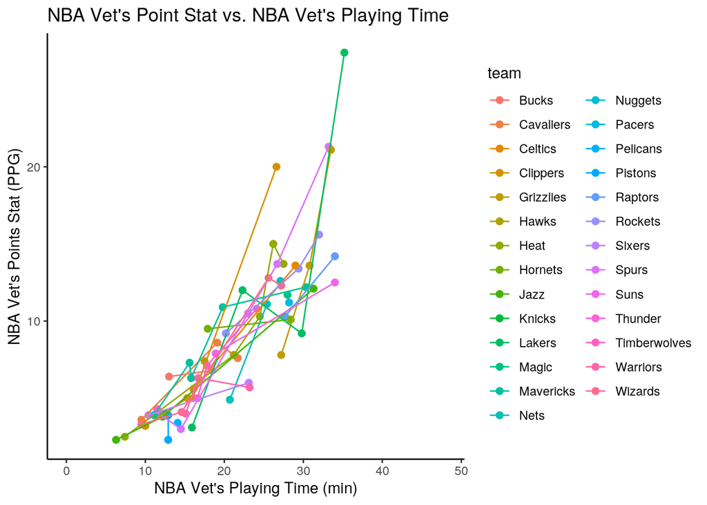

```r
NBAvetsPlot <- joinedNBAdata %>% filter(Age > 30)
ggplot(data = NBAvetsPlot, aes(x = MP, y = Points, color = team)) +
    geom_point(size = 2) + ggtitle("NBA Vet's Point Stat vs. NBA Vet's Playing Time") +
    ylab("NBA Vet's Points Stat (PPG)") + xlab("NBA Vet's Playing Time (min)") +
    geom_line() + scale_x_continuous(lim = c(0, 48)) + theme_classic()
```

```r
# your plot 2
joinedNBAdata %>% filter(Age < 21)
```

```
## # A tibble: 31 x 17
##    Name  Weight   Age Salary Points Blocks Steals Assists Rebounds `FT%` `FG%`
##    <chr>  <dbl> <dbl>  <dbl>  <dbl>  <dbl>  <dbl>   <dbl>    <dbl> <dbl> <dbl>
##  1 Jarr…    237    20 2.03e6   10.9    1.5    0.5     1.4      8.4 0.709 0.59
##  2 Dean…    250    20 8.17e6   16.3    0.9    0.9     1.8     10.3 0.746 0.585
##  3 Marv…    234    19 7.31e6   14.9    1      0.5     1        7.6 0.691 0.504
##  4 Isaa…    180    19 1.00e6    0.9    0.2    0.4     0.7      1.1 0.6   0.152
##  5 Mile…    225    20 3.21e6    7.5    0.6    0.7     1.2      4   0.753 0.464
##  6 Troy…    215    19 2.75e6    4.8    0.1    0.4     1.5      2.8 0.681 0.415
##  7 Wend…    255    19 4.44e6   10.3    1.3    0.6     1.8      7   0.795 0.485
##  8 Hami…    198    20 8.38e5    3.7    0.2    0.4     0.3      1.9 0.61  0.455
##  9 Luka…    218    19 6.56e6   21.2    0.3    1.1     6        7.8 0.713 0.427
## 10 Terr…    190    20 2.12e6    6.9    0.2    0.5     1        1.9 0.725 0.429
## # … with 21 more rows, and 6 more variables: MP <dbl>, team <chr>,
## #   team_abbr <chr>, position <chr>, number <dbl>, height <dbl>
```

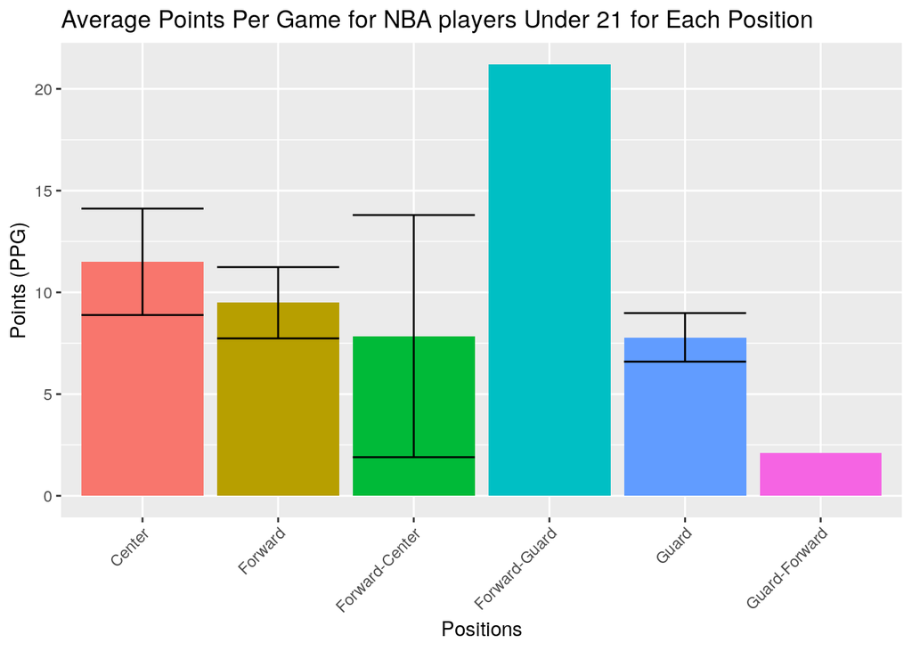

```r
NBAyoung <- joinedNBAdata %>% filter(Age < 21)
ggplot(NBAyoung, aes(x = position, y = Points, fill = position)) +
    geom_bar(stat = "summary", fun = mean) + geom_errorbar(stat = "summary",
    fun.data = mean_se) + ggtitle("Average Points Per Game for NBA players Under 21 for Each Position") +
    ylab("Points (PPG)") + xlab("Positions") + scale_y_continuous(breaks = seq(0,
    20, 5)) + theme(axis.text.x = element_text(angle = 45, hjust = 1),
    legend.position = "none")
```

*Before making the plot, a subset data was created from the joinedNBAdata just including NBA young players (younger than 21). A bar graph was generated utilizing the geom_bar function. The stat = “summary” function was utilized in order to display the mean values of the points per game for each position. Additionally, standard error bars were added utilizing geom_errorbar. The Y axis was adjusted to a range of 0 to 20 points in increments of 5. This bar clearly demonstrates that among NBA players who are younger than 21, the forward-guard players averaged the most points per game*

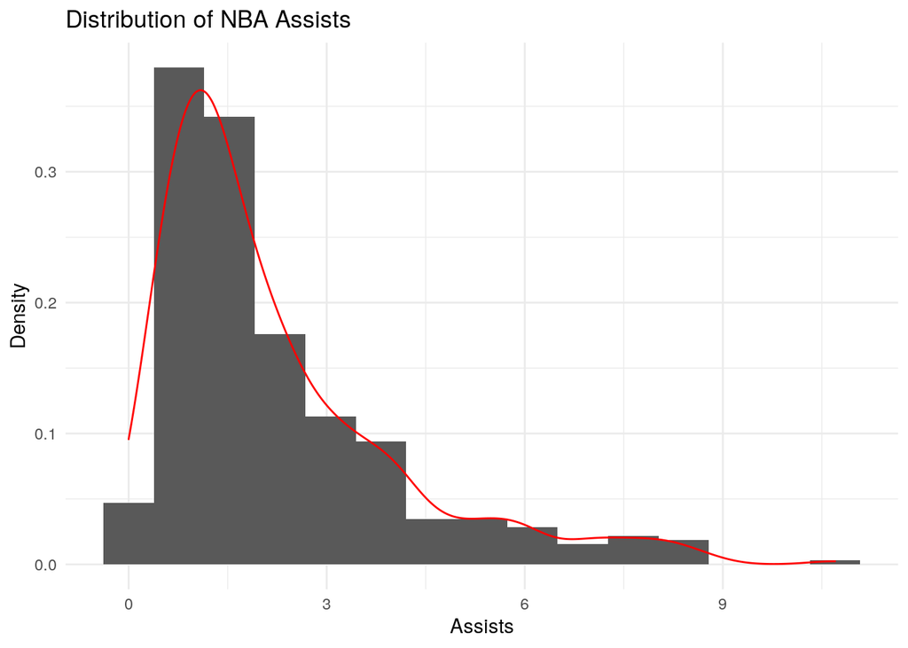

```r
# your plot 3
ggplot(joinedNBAdata, aes(x = Assists, y = ..density..)) + geom_histogram(bins = 15) +
    geom_density(color = "red") + ggtitle("Distribution of NBA Assists") +
    ylab("Density") + xlab("Assists") + scale_x_continuous(breaks = seq(0,
    12, 3)) + theme_minimal()
```

*With the joinedNBAdata set, a combo of a histogram and density plot was generated utilizing geom_histogram and geom_density. This plot displays the distribution of players for the different numbers of assists. The plot clearly shows how most of the NBA players are in between 0.75 and 4.5 assists per game indicated by the high density curve in that region and the high bars as well.*